# Project 1

Carla Brookey, Fred Hintz, Thanh Tran, Kassidie Stokes

March 21, 2017

First we read in the data to R.

```r
HP.train <- read.csv('train.csv', sep = ',', header = TRUE)
HP.test <- read.csv('test.csv', sep = ',', header = TRUE)
HP.train$Id <- NULL
HP.test.Id <- HP.test$Id
HP.test$Id <- NULL
HP.test$SalePrice <- replicate(nrow(HP.test), 0)
ntrain <- nrow(HP.train)
ntest <- nrow(HP.test)
HP.all <- rbind(HP.train, HP.test)
```

Then we created functions to check for and deal with missing values. We chose to encode categorical missing values as a separate “missing” category and to code missing continuous values as the mean of the variable. We determined that mean imputation prior to doing the variable selection technique was preferable because we were not certain that the variables we coded provided much predictive information. If they turned out to be important after performing variable selection, we decided that we would deal with the missing values more appropriately.

```r
check_missing_values <- function(dataSet)
{
  for (i in seq(1,ncol(dataSet))) {
    num_NA = sum(is.na(dataSet[, i]))
    is_numeric = is.numeric(dataSet[,i])
    if (num_NA > 0) {
      print (paste0('column ', names(dataSet)[i],' has #missing values: ', num_NA, ' is numeric: ',is_numeric ))
    }
  }
}
check_categorical_variables <- function(dataSet)
{
  print('************************************************')
  print('Listing all variables with categorical values:')
  count <- 0
  for (i in 1:ncol(dataSet)) {
    if (!is.numeric(dataSet[,i])) {
      count <- count + 1
      factor_names <- paste(levels(dataSet[,i]), sep=" ")
      print (paste0(names(dataSet)[i], ' is categorical variable with number of factors: '))
      print (factor_names)
    }
  }
  print (paste0('Total categorical variables:' , count))
  print('************************************************')
}

deal_missing_values <- function(dataSet, ntrain = 1460, type = 1)
{
  # type is the replace method for numeric values.
  #if type = 1 --> using mean to replace.
  #if type = 2 --> using median to replace.
  dataSet[] <- lapply(dataSet, function(x){
    # check if variables have a factor:
    if(!is.factor(x)) {
      #replace NA by mean
      if (type == 1) x[is.na(x)] <- mean(x[1:1460], na.rm = TRUE)
      else if (type == 2) if (type == 1) x[is.na(x)] <- median(x[1:1460], na.rm = TRUE)
    }
    else {
      # otherwise include NAs into factor levels and change factor levels:
      x <- factor(x, exclude=NULL)
      levels(x)[is.na(levels(x))] <- "Missing"
    }
    return(x)
  })

  return(dataSet)
}

#
# encoding categorical variables. If a variable has 3 levels --> we need 2 bit to encode
#
```

The following function was used to expand the categorical variables into dummy variables for the regression.

```r
encode_categorical_variables <- function(dataSet, ntrain=1460)
{
  dataSetTemp <- dataSet
  for (i in 1:ncol(dataSet)){
    if (is.factor(dataSet[,i])) {
      col_name = names(dataSet)[i]
      t <- model.matrix(~ factor(dataSet[,i]) - 1)
      dataSetTemp <- cbind(t[,2:ncol(t)], dataSetTemp)
      new_col_names <- paste(col_name, "_bit", seq(1, ncol(t) - 1))
      names(dataSetTemp)[1:ncol(t) - 1] <- new_col_names
    }
  }
  removed <- c()
  for (i in 1:ncol(dataSetTemp)) {
    if (is.factor(dataSetTemp[,i])) removed <- c(removed, i)
  }
  dataSetTemp <- dataSetTemp[, -removed]
  return(dataSetTemp)
}
```

This function was one approach we used to identify outliers. It deletes any observation with an observation on any variable more than 1.5*IQR beyond the 25th and 75th percentile. We determined it wasn’t useful for us because it deleted the entire dataset.

```r
deal_outliers <- function(dataSet)
{
  for (i in 1:ncol(dataSet)) {
    if (is.numeric(dataSet[,i])) {
      lower_bound = as.integer(quantile(dataSet[,i], .25) - 1.5*IQR(dataSet[,i]))
      upper_bound = as.integer(quantile(dataSet[,i], .75) + 1.5*IQR(dataSet[,i]))
      dataSet <- dataSet[dataSet[,i] >  lower_bound & dataSet[,i] < upper_bound, ]
    }
  }
  return(dataSet)
}
```

```r
do_variable_selection <- function(dataSet)
{
  trainData <- dataSet[1:ntrain,]
  logSalePrice <- log(trainData$SalePrice)
  trainData <- cbind(trainData, logSalePrice)
  trainData$SalePrice <- NULL
  trainData.cv.lasso = cv.glmnet(x = as.matrix(trainData[,1:(ncol(trainData) - 1)]),
                             y=as.matrix(trainData[,ncol(trainData)]), alpha = 1)
  names(trainData.cv.lasso$lambda.1se)="Lambda 1 SE:"
  trainData.cv.lasso$lambda.1se
  trainData.lasso = glmnet(x = as.matrix(trainData[,1:(ncol(trainData) - 1)]),
                           y=as.matrix(trainData[,ncol(trainData)]), alpha = 1)
  co <- coef(trainData.lasso, s = trainData.cv.lasso$lambda.1se)
  co <- co[2:nrow(co),] #remove the coefficient of intercept, which is the first row
  trainData <- trainData[, co > 0]
  vars <- names(trainData)
  print('Important variables:')
  print(vars)
  vars <- c(vars, 'SalePrice')
  dataSet <- subset(dataSet, select = vars)
  return(dataSet)
}
```

## 1. Dealing with missing values for training and testing data

First we checked to see which variables contained missing values.

```r
check_missing_values(HP.all)
```

```
## [1] "column MSZoning has #missing values: 4 is numeric: FALSE"
## [1] "column LotFrontage has #missing values: 486 is numeric: TRUE"
## [1] "column Alley has #missing values: 2721 is numeric: FALSE"
## [1] "column Utilities has #missing values: 2 is numeric: FALSE"
## [1] "column Exterior1st has #missing values: 1 is numeric: FALSE"
## [1] "column Exterior2nd has #missing values: 1 is numeric: FALSE"
## [1] "column MasVnrType has #missing values: 24 is numeric: FALSE"
## [1] "column MasVnrArea has #missing values: 23 is numeric: TRUE"
## [1] "column BsmtQual has #missing values: 81 is numeric: FALSE"
## [1] "column BsmtCond has #missing values: 82 is numeric: FALSE"
## [1] "column BsmtExposure has #missing values: 82 is numeric: FALSE"
## [1] "column BsmtFinType1 has #missing values: 79 is numeric: FALSE"
## [1] "column BsmtFinSF1 has #missing values: 1 is numeric: TRUE"
## [1] "column BsmtFinType2 has #missing values: 80 is numeric: FALSE"
## [1] "column BsmtFinSF2 has #missing values: 1 is numeric: TRUE"
```

[output cut: 19 more lines]

```r
HP.all <- deal_missing_values(HP.all, ntrain)
print ('check missing values of the dataframe after replacing missing values. Should print blank')
```

```
## [1] "check missing values of the dataframe after replacing missing values. Should print blank"
```

```r
check_missing_values(HP.all)
```

# 2. Linear regression model with untransformed sale price data and residual analysis

```r
HP.train<-deal_missing_values(HP.train)


HP.train.lr_model <- lm(SalePrice~., HP.train)
```

# Residual vs Fitted Plot

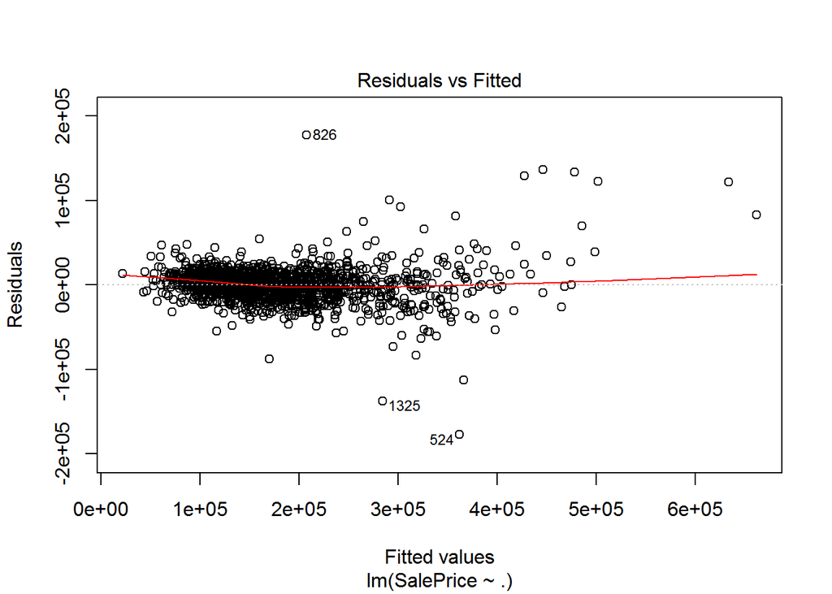

```r
plot(HP.train.lr_model, which=1)
```

There’s a pretty clear expansion in variance once the sale price goes above 3e+05. This Makes sense, since there are fewer homes at that price range. The base r plots point out that the 3 biggest outliers are obs. # 826, 1325, 524

# QQ plot

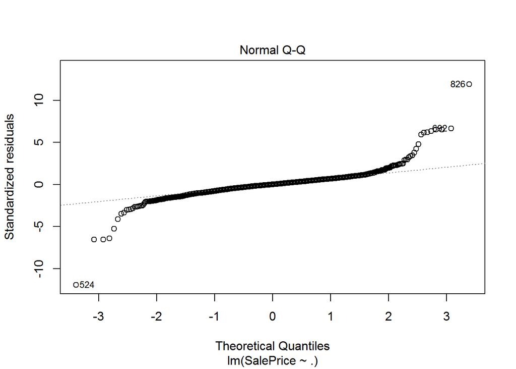

```r
plot(HP.train.lr_model, which=2)
```

The QQ plot looks pretty bad at the tails. Obs. 826 and 524 are again noted as outliers

# fitted values by square root of standardized residuals

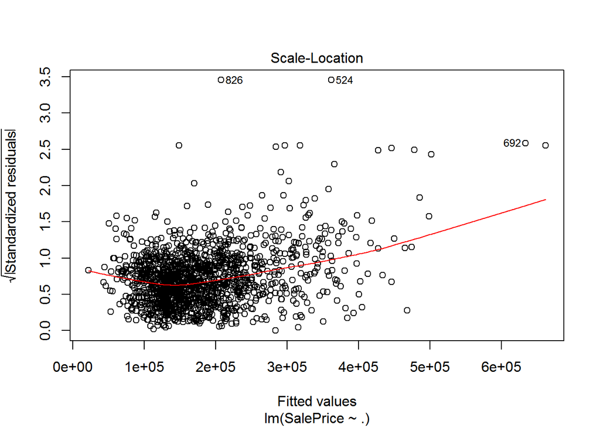

```r
plot(HP.train.lr_model, which=3)
```

From examining this plot, the error clearly increases at higher ends of sale price

# cook’s distance

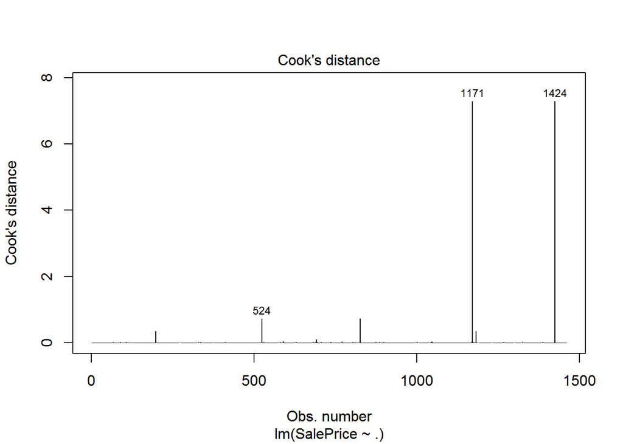

```r
plot(HP.train.lr_model, which=4)
```

3 outliers in terms of cook’s distance: 524, 1171, and 1424

# Leverage vs. standardized residuals

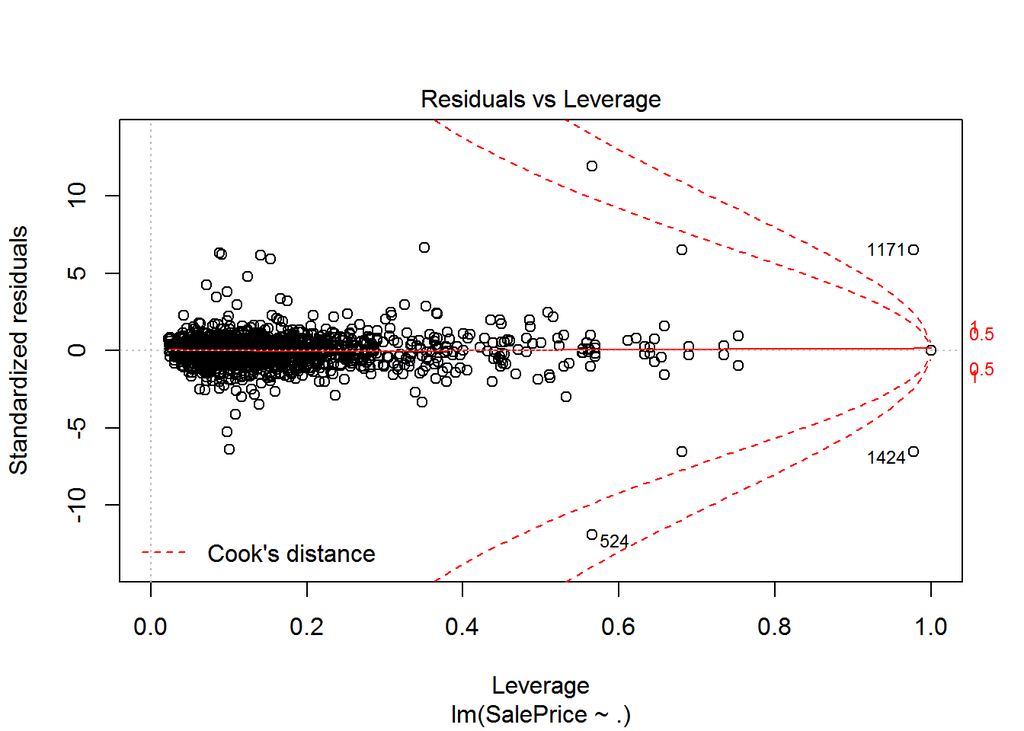

```r
plot(HP.train.lr_model, which=5)
```

observations with high leverage and high standardized residuals are the same that have high cook’s d

We have five clear outliers that need looking at. Log transform should help. These are: 524,826,1171,1325, 1424

Based on the residual plots, we determined that a log transform of the saleprice variable was appropriate.

# 3. Linear regression model with log transform of sale price data and residual analysis

```r
HP.trainlog<-HP.train %>% mutate(logSalePrice=log(SalePrice)) %>% select (-SalePrice)

HP.train_logtrans_mod<-lm(logSalePrice ~., HP.trainlog)
```

We looked at the same Plots again

The outliers from the untransformed model were 524,826,1171,1325, 1424

# Residuals vs fitted plot

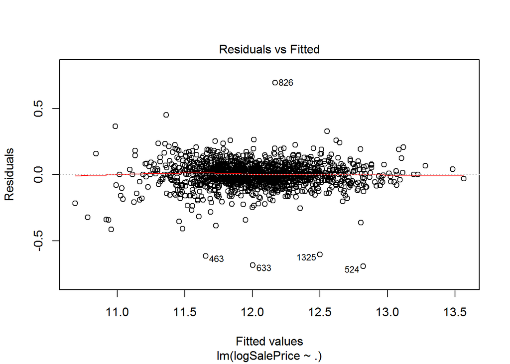

```r
plot(HP.train_logtrans_mod, which=1, id.n=5)
```

Residuals over .5 also now include observations 633 and 463

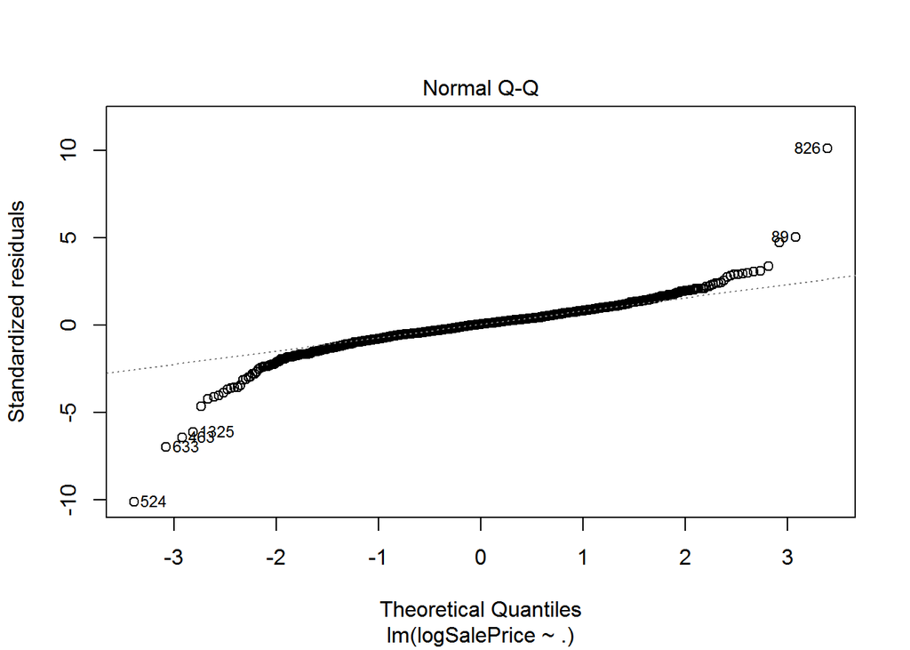

```r
plot(HP.train_logtrans_mod, which=2, id.n=6)
```

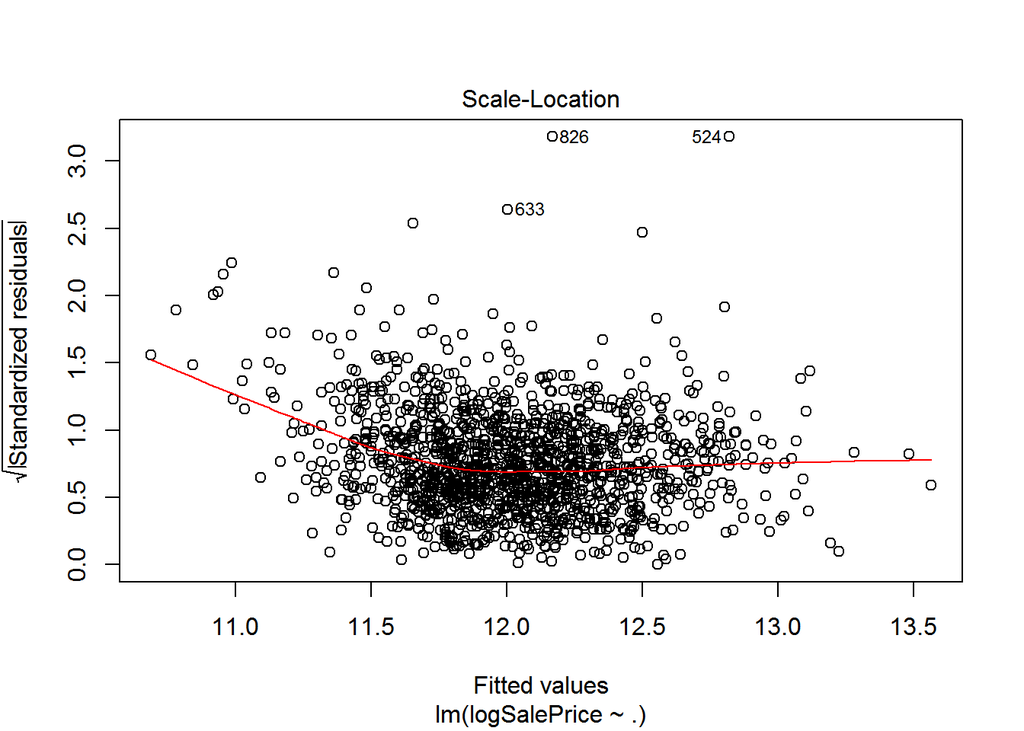

```r
plot(HP.train_logtrans_mod, which=3)
```

The scale-location plot looks far better for this model, although error is slightly higher at the lower end now. The same outliers are identified

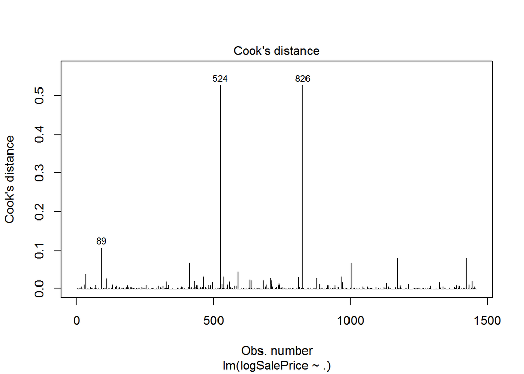

```r
plot(HP.train_logtrans_mod, which=4)
```

Obs. 89 is now identified as an influential observation by cook’s distance.

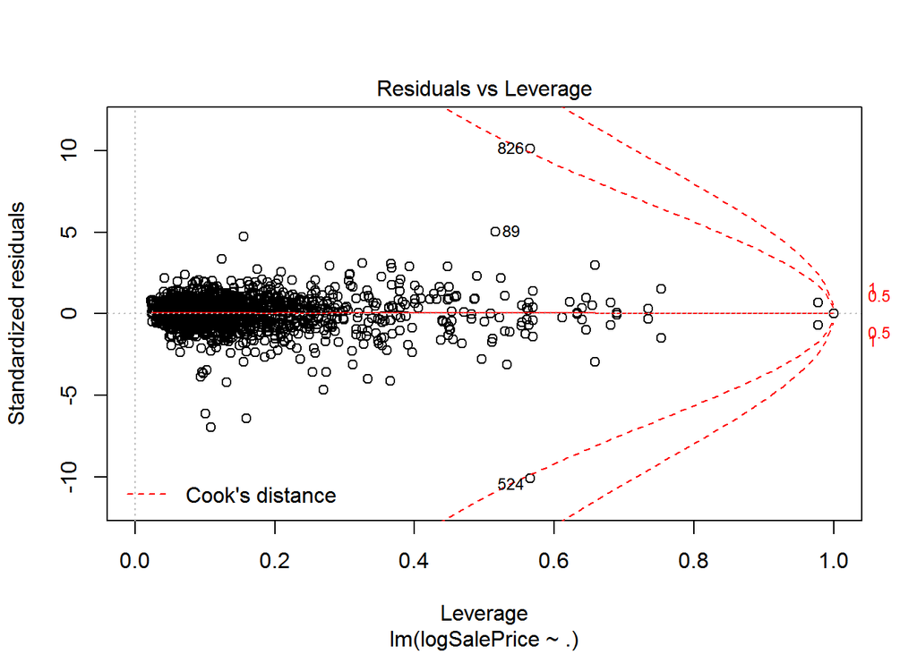

```r
plot(HP.train_logtrans_mod, which=5)
```

Only a few observations with high leverage and high standardized residuals, which we already knew about.

```r
cat("Log trans r squared is", summary(HP.train_logtrans_mod)$adj.r.squared)
```

```
## Log trans r squared is 0.9323392
```

```r
cat("\n untransformed r squared is", summary(HP.train.lr_model)$adj.r.squared)
```

```
##
##  untransformed r squared is 0.9192693
```

```r
cat(" \n Log trans F is", summary(HP.train_logtrans_mod)$fstatistic[[1]])
```

```
##
##  Log trans F is 80.46416
```

```r
cat("\n untransformed F is", summary(HP.train.lr_model)$fstatistic[[1]])
```

```
##
##  untransformed F is 66.66577
```

Comparing with the untransformed model, we get a higher adjusted R-squared and a higher F statistic when predicting the log transform of sale price.

# 2. Encoding categorical variables

Before conducting the lasso variable selection method , we constructed dummy variables for the categorical variables and transformed some quantitative variables to make them more interpretable.

```r
#check_categorical_variables(HP.train)

# HP.train <- encode_categorical_variables(HP.train)
HP.all <- encode_categorical_variables(HP.all)
print ('check categorical values of the dataframe after encoding. Should print blank')
```

```
## [1] "check categorical values of the dataframe after encoding. Should print blank"
```

```r
check_categorical_variables(HP.all)
```

```
## [1] "************************************************"
## [1] "Listing all variables with categorical values:"
## [1] "Total categorical variables:0"
## [1] "************************************************"
```

```r
#reconstruct some variables:
HP.all <- mutate(HP.all,
                 house_age = YrSold + MoSold/12 - YearBuilt,
                 remodel_house_age = abs(YearRemodAdd - YearBuilt),
                 gara_age = abs(GarageYrBlt - YearBuilt),
                 sold_year_to_now = 2017 - YrSold - MoSold/12,
                 built_year_to_now = 2017 - YearBuilt

)

SalePrice <- HP.all$SalePrice
HP.all$SalePrice <- NULL
HP.all$SalePrice <- SalePrice
HP.all$GarageYrBlt <- NULL
HP.all$YearBuilt <- NULL
HP.all$YearRemodAdd <- NULL
HP.all$YrSold <- NULL
HP.all$MoSold <- NULL
```

Here we perform the variable selection method. The variable selection function also creates a subset of the chosen variables to use in the model.

```r
HP.all <- do_variable_selection(HP.all)
```

```
## [1] "Important variables:"
##  [1] "SaleType _bit 6"      "PavedDrive _bit 2"    "Functional _bit 6"
##  [4] "CentralAir _bit 1"    "BsmtExposure _bit 1"  "Foundation _bit 2"
##  [7] "Exterior1st _bit 3"   "RoofMatl _bit 7"      "Condition1 _bit 2"
## [10] "Neighborhood _bit 6"  "Neighborhood _bit 13" "Neighborhood _bit 15"
## [13] "Neighborhood _bit 21" "LotConfig _bit 1"     "LotArea"
## [16] "OverallQual"          "OverallCond"          "BsmtFinSF1"
## [19] "TotalBsmtSF"          "X1stFlrSF"            "GrLivArea"
## [22] "BsmtFullBath"         "HalfBath"             "Fireplaces"
## [25] "GarageCars"           "WoodDeckSF"           "ScreenPorch"
```

```r
HP.train = HP.all[1:ntrain,]
HP.test = HP.all[(ntrain+1) : nrow(HP.all),]
HP.test$SalePrice <- NULL
```

We then performed a linear regression with the lassoed variables on the log of the sale price. and looked at the residual plots.

```r
#*******************************************************************************
###Multiple linear regression model with lassoed variables
#Make a new dataset with log of sale price
HP.train<-HP.all[1:ntrain,]

HP.trainlog_sub<-HP.train %>% mutate(logSalePrice=log(SalePrice)) %>% select(-SalePrice)

#Run a linear model on the log of sale price
HP_subset_linmod<-lm(logSalePrice ~ ., data=HP.trainlog_sub)

#View summary of model, R-Squared is still good
summary(HP_subset_linmod)
```

```
##
## Call:
## lm(formula = logSalePrice ~ ., data = HP.trainlog_sub)
##
## Residuals:
##       Min        1Q    Median        3Q       Max
## -0.114890 -0.004834  0.000971  0.006211  0.041319
##
## Coefficients:
##                         Estimate Std. Error t value Pr(>|t|)
## (Intercept)            1.9745712  0.0109936 179.610  < 2e-16 ***
## `SaleType _bit 6`      0.0089488  0.0012037   7.435 1.80e-13 ***
## `PavedDrive _bit 2`    0.0055007  0.0012205   4.507 7.12e-06 ***
## `Functional _bit 6`    0.0068823  0.0012609   5.458 5.65e-08 ***
## `CentralAir _bit 1`    0.0082591  0.0013786   5.991 2.64e-09 ***
## `BsmtExposure _bit 1`  0.0041270  0.0011168   3.695 0.000228 ***
## `Foundation _bit 2`    0.0096033  0.0008153  11.779  < 2e-16 ***
## `Exterior1st _bit 3`   0.0049139  0.0016815   2.922 0.003528 **
## `RoofMatl _bit 7`      0.0120097  0.0047429   2.532 0.011444 *
## `Condition1 _bit 2`    0.0061012  0.0008957   6.812 1.42e-11 ***
## `Neighborhood _bit 6`  0.0070993  0.0016997   4.177 3.14e-05 ***
## `Neighborhood _bit 13` 0.0074909  0.0019398   3.862 0.000118 ***
## `Neighborhood _bit 15` 0.0115318  0.0014872   7.754 1.68e-14 ***
## `Neighborhood _bit 21` 0.0120307  0.0023876   5.039 5.28e-07 ***
## `LotConfig _bit 1`     0.0045831  0.0012553   3.651 0.000271 ***
## LotArea                0.0067862  0.0007072   9.596  < 2e-16 ***
## OverallQual            0.0418136  0.0024983  16.737  < 2e-16 ***
## OverallCond            0.0208861  0.0019865  10.514  < 2e-16 ***
## BsmtFinSF1             0.0008839  0.0001340   6.595 5.98e-11 ***
## TotalBsmtSF            0.0003885  0.0002960   1.313 0.189461
## X1stFlrSF              0.0116144  0.0015564   7.462 1.47e-13 ***
## GrLivArea              0.0265931  0.0015922  16.702  < 2e-16 ***
## BsmtFullBath           0.0045076  0.0011065   4.074 4.88e-05 ***
## HalfBath               0.0050693  0.0011716   4.327 1.62e-05 ***
## Fireplaces             0.0030503  0.0009353   3.261 0.001136 **
## GarageCars             0.0121181  0.0012143   9.980  < 2e-16 ***
## WoodDeckSF             0.0005164  0.0001258   4.105 4.27e-05 ***
## ScreenPorch            0.0004809  0.0002193   2.193 0.028503 *
## ---
## Signif. codes:  0 '***' 0.001 '**' 0.01 '*' 0.05 '.' 0.1 ' ' 1
##
## Residual standard error: 0.0113 on 1432 degrees of freedom
## Multiple R-squared:  0.8863, Adjusted R-squared:  0.8842
## F-statistic: 413.6 on 27 and 1432 DF,  p-value: < 2.2e-16
```

# Examining outliers from lassoed variable regression

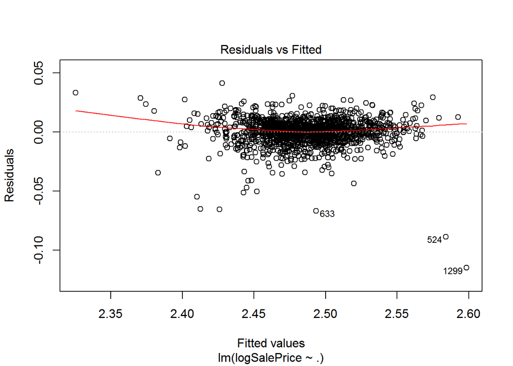

```r
plot(HP_subset_linmod,which=1)
```

A few houses are severely overestimated. Why is this? Check out cases 633, 524, and 1299, increasing in order of severity

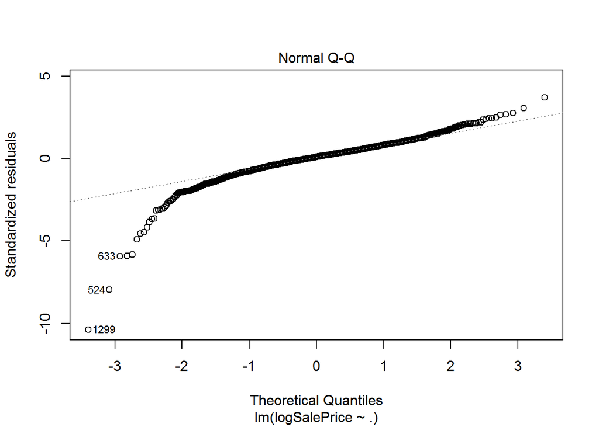

```r
plot(HP_subset_linmod, which=2)
```

The same three outliers show up in qq plot, unsurprisingly

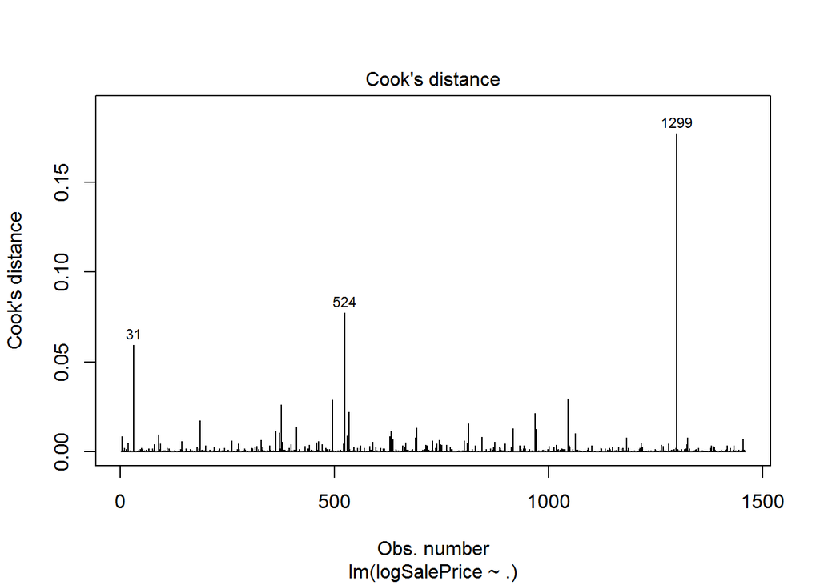

```r
plot(HP_subset_linmod, which=4)
```

Note that from this plot, 31 may also be an outlier, but if it is overestimated, we may not need to worry about it

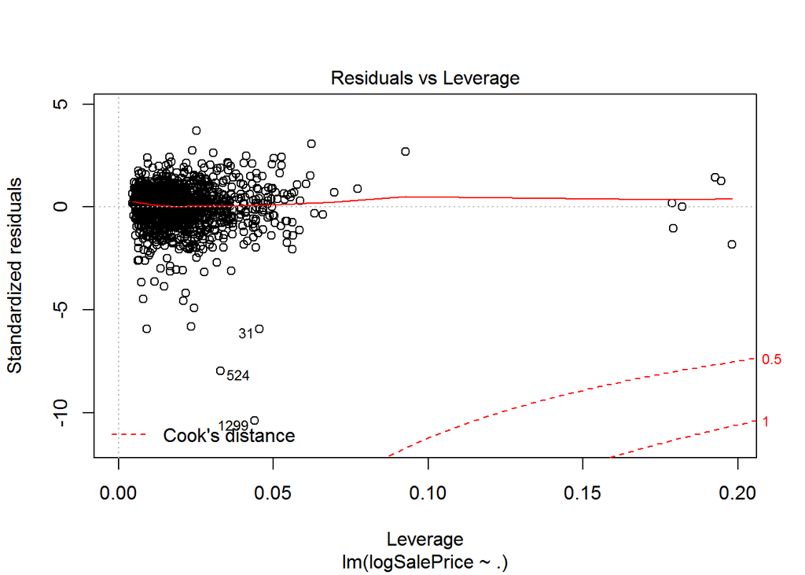

```r
plot(HP_subset_linmod, which=5)
```

Look at these three points in detail

```r
HP.train[c(524,633,1299),]
```

```
##      SaleType _bit 6 PavedDrive _bit 2 Functional _bit 6 CentralAir _bit 1
## 524                1                 1                 1                 1
## 633                0                 1                 1                 1
## 1299               1                 1                 1                 1
##      BsmtExposure _bit 1 Foundation _bit 2 Exterior1st _bit 3
## 524                    1                 1                  0
## 633                    0                 0                  0
## 1299                   1                 1                  0
##      RoofMatl _bit 7 Condition1 _bit 2 Neighborhood _bit 6
## 524                0                 0                   0
## 633                0                 1                   0
## 1299               0                 0                   0
##      Neighborhood _bit 13 Neighborhood _bit 15 Neighborhood _bit 21
## 524                     0                    0                    0
## 633                     0                    0                    0
## 1299                    0                    0                    0
##      LotConfig _bit 1   LotArea OverallQual OverallCond BsmtFinSF1
## 524                 0 10.599007    2.397895    1.791759   7.723562
## 633                 0  9.384378    2.079442    1.791759   6.712956
## 1299                0 11.064887    2.397895    1.791759   8.638525
##      TotalBsmtSF X1stFlrSF GrLivArea BsmtFullBath  HalfBath Fireplaces
## 524     8.051660  8.051660  8.450412    0.6931472 0.6931472  0.6931472
## 633     7.234898  7.252762  7.252762    0.0000000 0.0000000  0.6931472
## 1299    8.717846  8.453827  8.638171    1.0986123 0.6931472  1.3862944
##      GarageCars WoodDeckSF ScreenPorch SalePrice
## 524    1.386294   5.342334           0  12.12676
## 633    1.098612   5.262690           0  11.32057
## 1299   1.098612   5.370638           0  11.98294
```

```r
no_outliers<-c(1:523,525:1298,1300:1460)

HP_subset_linmod_noout<-lm(logSalePrice ~ .,
                           data=HP.trainlog_sub,
                           subset=no_outliers)

summary(HP_subset_linmod_noout)
```

```
##
## Call:
## lm(formula = logSalePrice ~ ., data = HP.trainlog_sub, subset = no_outliers)
##
## Residuals:
##       Min        1Q    Median        3Q       Max
## -0.066906 -0.005013  0.000828  0.006079  0.040730
##
## Coefficients:
##                         Estimate Std. Error t value Pr(>|t|)
## (Intercept)            1.9532747  0.0104034 187.754  < 2e-16 ***
## `SaleType _bit 6`      0.0106980  0.0011340   9.434  < 2e-16 ***
## `PavedDrive _bit 2`    0.0055573  0.0011430   4.862 1.29e-06 ***
## `Functional _bit 6`    0.0072568  0.0011811   6.144 1.04e-09 ***
## `CentralAir _bit 1`    0.0079359  0.0012913   6.146 1.03e-09 ***
## `BsmtExposure _bit 1`  0.0052715  0.0010491   5.025 5.68e-07 ***
## `Foundation _bit 2`    0.0096615  0.0007635  12.653  < 2e-16 ***
## `Exterior1st _bit 3`   0.0044881  0.0015750   2.850 0.004439 **
## `RoofMatl _bit 7`      0.0094259  0.0044454   2.120 0.034147 *
## `Condition1 _bit 2`    0.0051477  0.0008416   6.117 1.23e-09 ***
## `Neighborhood _bit 6`  0.0067188  0.0015920   4.220 2.59e-05 ***
## `Neighborhood _bit 13` 0.0062917  0.0018186   3.460 0.000557 ***
## `Neighborhood _bit 15` 0.0100364  0.0013967   7.186 1.07e-12 ***
## `Neighborhood _bit 21` 0.0108407  0.0022375   4.845 1.40e-06 ***
## `LotConfig _bit 1`     0.0039858  0.0011763   3.388 0.000722 ***
## LotArea                0.0072007  0.0006629  10.862  < 2e-16 ***
## OverallQual            0.0421932  0.0023399  18.032  < 2e-16 ***
## OverallCond            0.0210071  0.0018604  11.292  < 2e-16 ***
## BsmtFinSF1             0.0009339  0.0001256   7.437 1.77e-13 ***
## TotalBsmtSF            0.0003575  0.0002772   1.290 0.197328
## X1stFlrSF              0.0130710  0.0014612   8.945  < 2e-16 ***
## GrLivArea              0.0277142  0.0014932  18.560  < 2e-16 ***
## BsmtFullBath           0.0047778  0.0010366   4.609 4.40e-06 ***
## HalfBath               0.0056896  0.0010981   5.182 2.52e-07 ***
## Fireplaces             0.0028165  0.0008766   3.213 0.001343 **
## GarageCars             0.0109645  0.0011403   9.616  < 2e-16 ***
## WoodDeckSF             0.0005214  0.0001178   4.426 1.03e-05 ***
## ScreenPorch            0.0004008  0.0002055   1.950 0.051319 .
## ---
## Signif. codes:  0 '***' 0.001 '**' 0.01 '*' 0.05 '.' 0.1 ' ' 1
##
## Residual standard error: 0.01058 on 1430 degrees of freedom
## Multiple R-squared:  0.9005, Adjusted R-squared:  0.8986
## F-statistic: 479.1 on 27 and 1430 DF,  p-value: < 2.2e-16
```

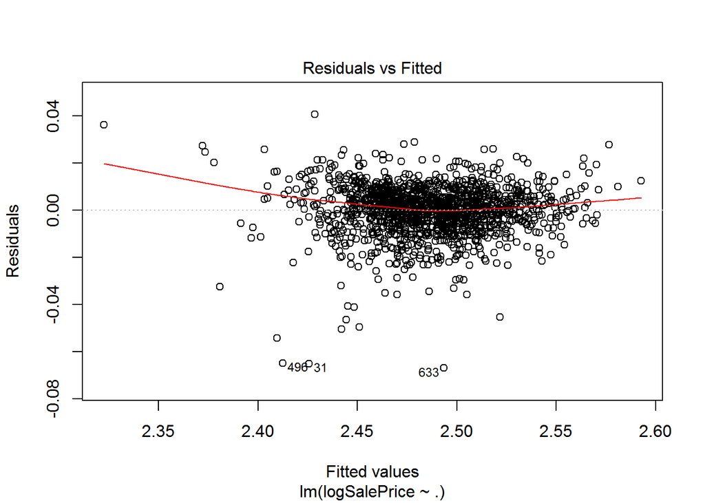

```r
plot(HP_subset_linmod_noout,which=1)
```

```r
#write to file
HP.test$SalePrice <- predict(HP_subset_linmod_noout, HP.test)
submission <- data.frame(Id <- HP.test.Id, SalePrice <- HP.test$SalePrice)
names(submission) <- c('Id', 'SalePrice')
write.csv(file = 'submission.csv', x = submission, row.names = FALSE)
```

Our prediction RMSLE was #0.13025